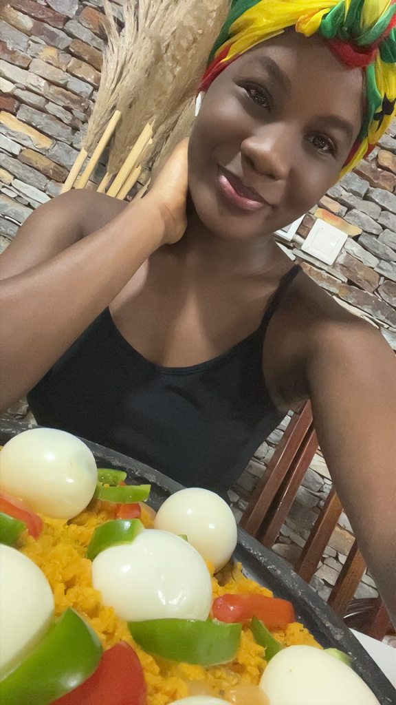

# Noreen Irena Ghartey

## About Me

I am a trained medical doctor from Ghana, now residing in Columbia, MD. Currently I am a full-time graduate student at [Johns Hopkins Bloomberg School of Public Health](https://publichealth.jhu.edu/). I am interested in research that sits at the intersection of digital health and pediatrics. I have used [Stata](https://www.stata.com/) in the past and have learned [Python](https://www.python.org/) but I never really worked with them so all of this feels very new to me. I hope to gain confidence in using [R](https://www.r-project.org/) by the end of this course.

## Fun Facts

I play multiple sports for fun, especially tennis and volleyball. I love arts and cooking. I used to vlog and share on my [YouTube channel](https://youtu.be/IaBg6_1V8fE?is=IuQ8Pt-MiBtBqYX5). Although it’s been 4 years since I put anything on there, watching those videos back is so refreshing and often helps me deal with mental stress.

## Something I Find Inspiring

As a physician with a strong interest in adolescent and maternal health, I find the work of the [Empower Her Initiative by Brazza International Foundation](https://www.brazzainternational.org/) especially inspiring because it recognizes that empowering adolescent mothers requires more than healthcare; it requires equipping them with knowledge, support, and opportunities to build healthier and more empowered futures.